# Prediction of amyloidogenicity based on the n-gram analysis

28-06-2016

## Outline

1. Amyloids and hot spots.
2. n-gram analysis.
3. Encoding of amino acids.
4. Quick Permutation Test.
5. Best-performing encoding.
6. Benchmark.

## Amyloids

Proteins associated with various neurodegenerative disorders (e.g., Alzheimer's, Parkinson'a's, Creutzfeldta-Jakob'a's diseases) creating harmful aggregates.

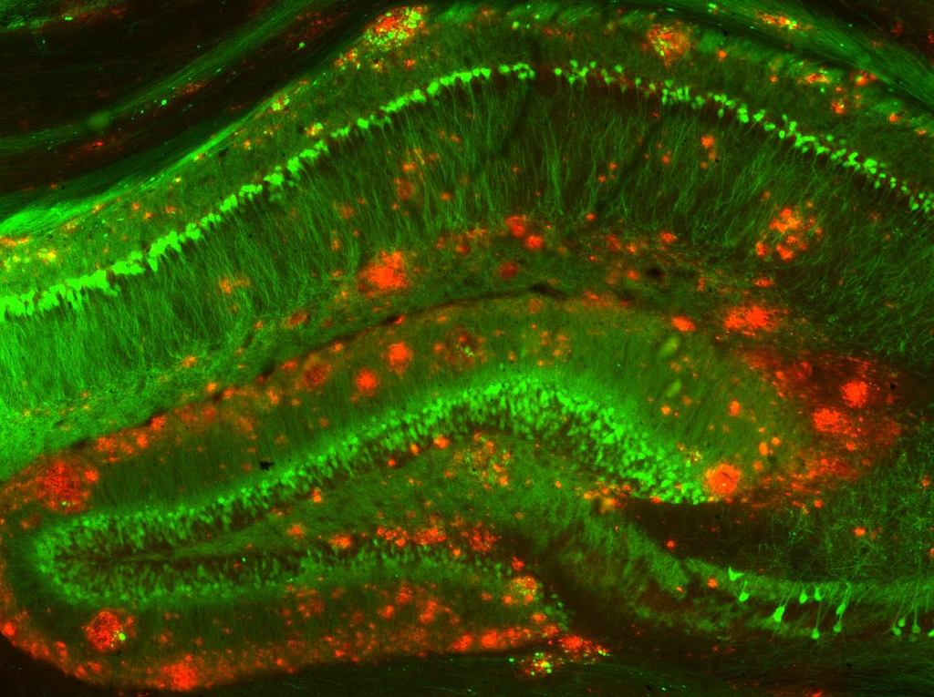

Amyloid aggregates (red) around neurons (green). Strittmatter Laboratory, Yale University

## Hot spots

The aggregation of amyloids is initiated by 6- to 15-residue segments called hot spots, diverse subsequences that form unique zipper-like \(\beta\)-structures.

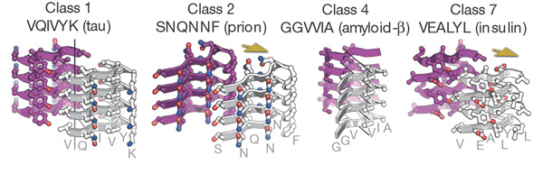

Sawaya et al. (2007)

## Aim

Analize structure of hot spots and create a novel predictor of amyloids.

## n-grams

Sample sequences. S - sequence, P - position.

|  | P1 | P2 | P3 | P4 | P5 | P6 |
| --- | --- | --- | --- | --- | --- | --- |
| S1 | G | W | W | C | Q | L |
| S2 | I | F | Q | F | I | R |
| S3 | N | V | P | E | S | Y |

### 1-grams:

### G, I, N

## n-grams

Sample sequences. S - sequence, P - position.

|  | P1 | P2 | P3 | P4 | P5 | P6 |
| --- | --- | --- | --- | --- | --- | --- |
| S1 | G | W | W | C | Q | L |
| S2 | I | F | Q | F | I | R |
| S3 | N | V | P | E | S | Y |

### 2-grams:

### GW, IF, NV

## n-grams

Sample sequences. S - sequence, P - position.

|  | P1 | P2 | P3 | P4 | P5 | P6 |
| --- | --- | --- | --- | --- | --- | --- |
| S1 | G | W | W | C | Q | L |
| S2 | I | F | Q | F | I | R |
| S3 | N | V | P | E | S | Y |

### 3-grams:

### GWW, IFQ, NVP

## n-grams

Sample sequences. S - sequence, P - position.

|  | P1 | P2 | P3 | P4 | P5 | P6 |
| --- | --- | --- | --- | --- | --- | --- |
| S1 | G | W | W | C | Q | L |
| S2 | I | F | Q | F | I | R |
| S3 | N | V | P | E | S | Y |

### 2-grams (gaps between elements 1):

### G-W, I-Q, N-P

## n-grams

Sample sequences. S - sequence, P - position.

|  | P1 | P2 | P3 | P4 | P5 | P6 |
| --- | --- | --- | --- | --- | --- | --- |
| S1 | G | W | W | C | Q | L |
| S2 | I | F | Q | F | I | R |
| S3 | N | V | P | E | S | Y |

### 2-grams (gaps between elements 2):

### G–C, I–F, N–E

## n-grams

Sample sequences. S - sequence, P - position.

|  | P1 | P2 | P3 | P4 | P5 | P6 |
| --- | --- | --- | --- | --- | --- | --- |
| S1 | G | W | W | C | Q | L |
| S2 | I | F | Q | F | I | R |
| S3 | N | V | P | E | S | Y |

### 3-grams (gaps between elements 1):

### G-W-Q, I-Q-I, N-P-S

## n-grams

Sample sequences. S - sequence, P - position.

|  | P1 | P2 | P3 | P4 | P5 | P6 |
| --- | --- | --- | --- | --- | --- | --- |
| S1 | G | W | W | C | Q | L |
| S2 | I | F | Q | F | I | R |
| S3 | N | V | P | E | S | Y |

### 3-grams (gaps between elements 0 and 1):

### GW-C, IF-F, NV-E

## Quick Permutation Test

Informative n-grams are usually selected using permutation tests.

During a permutation test we shuffle randomly class labels and compute a defined statistic (e.g. information gain). Values of statistic for permuted data are compared with the value of statistic for original data.

\[ \textrm{p-value} = \frac{N_{T_P > T_R}}{N} \]

\(N_{T_P > T_R}\): number of cases, where \(T_P\) (permuted test statistic) has more extreme values than \(T_R\) (test statistic for original data).

\(N\): number of permutations.

## QuiPT

**Qui**ck **P**ermutation **T**est is a fast alternative to permutation tests for n-gram data. It also allows precise estimation of p-value.

QuiPT is avaible as part of the **biogram** R package.

## Encoding of amino acids

Amino acid alphabets containing 10-12 letters can be used to design foldable sequences for a large number of protein families (Murphy, Wallqvist, and Levy 2000).

## Encoding of amino acids

| Name | Elements |
| --- | --- |
| 1 | G |
| 2 | K, P, R |
| 3 | I, L, V |
| 4 | F, W, Y |
| 5 | A, C, H, M |
| 6 | D, E, N, Q, S, T |

Example: GPRS – 1226.

## Reduced dimensionality

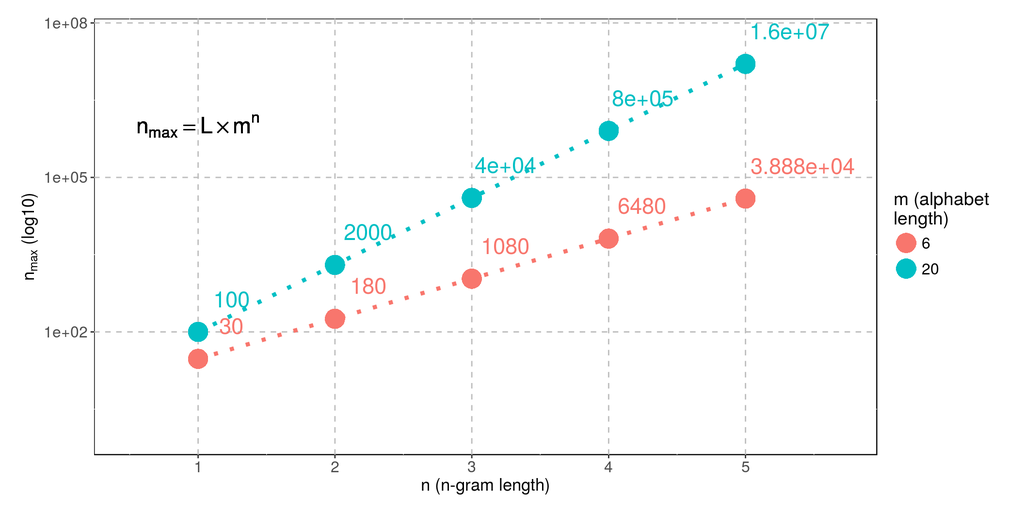

## Creation of encodings

We created 524 284 encodings with different levels of amino acid alphabet reduction, from three to six groups of amino acid which was performed on all combinations of the normalized values of 17 handpicked physicochemical properties from AAIndex database (Kawashima et al. 2008).

## Selection of the best-performing encoding

We cross-validated 18,535 random forests classifiers (Wright and Ziegler 2015) on unique amino acid encodings to identify the best-performing encoding.

We trained several iterations of each classifier on amyloidogenic and non-amyloidogenic sequences with different length.

## Selection of the best-performing encoding

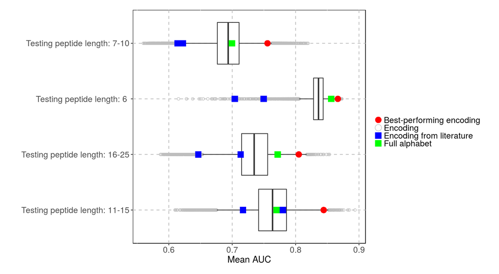

## Best-performing encoding

| Name | Elements |
| --- | --- |
| 1 | G |
| 2 | K, P, R |
| 3 | I, L, V |
| 4 | F, W, Y |
| 5 | A, C, H, M |
| 6 | D, E, N, Q, S, T |

## Best-performing encoding

| Name | Elements |
| --- | --- |
| 1 | G |
| 2 | K, P, R |
| 3 | I, L, V |
| 4 | F, W, Y |
| 5 | A, C, H, M |
| 6 | D, E, N, Q, S, T |

Amino acids K, P, R are known \(\beta\)-breakers and should not occur in amyloids. (Paz and Serrano 2004).

## Best-performing encoding

| Name | Elements |
| --- | --- |
| 1 | G |
| 2 | K, P, R |
| 3 | I, L, V |
| 4 | F, W, Y |
| 5 | A, C, H, M |
| 6 | D, E, N, Q, S, T |

Hydrophobic amino acids are typical for amyloids (Doran et al. 2012).

## Informative n-grams

During analysis we identified 65 most informative n-grams. Part of them was experimentally confirmed (Paz and Serrano 2004).

## Informative n-grams

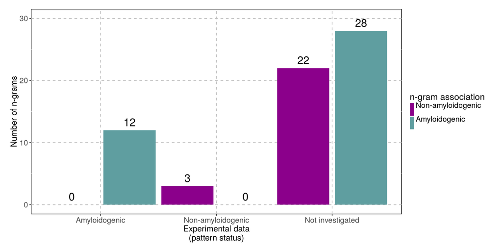

## AmyloGram

We used best-performing alphabet, AmyloGram, to create a novel predictor of amyloidogenicity based on n-grams.

## AmyloGram - benchmark

| Software | AUC | MCC |
| --- | --- | --- |
| PASTA2 | 0.854996271439225 | 0.429123592940917 |
| FoldAmyloid | 0.735098185433756 | 0.45255292317694 |
| appnn | 0.834302759134974 | 0.582260193831285 |
| AmyloGram | 0.897153865274671 | 0.630749412736651 |

## Summary and perspectives

- Cross-validate n-gram model.
- Define optimal length of the alphabet.
- Experimentally verify n-gram motifs.

## Acknowledgements

- Piotr Sobczyk.
- Paweł Mackiewicz.
- Małgorzata Kotulska.

Computations were carried out in Wroclaw Center for Networking and Supercomputing (http://www.wcss.pl) and funded by the institutional grant No. 347. This research was partially funded by the KNOW Consortium and National Science Center (2015/17/N/NZ2/01845).

## References

Doran, Todd M., Alissa J. Kamens, Nadia K. Byrnes, and Bradley L. Nilsson. 2012. “Role of Amino Acid Hydrophobicity, Aromaticity, and Molecular Volume on IAPP(20-29) Amyloid Self-Assembly.” *Proteins* 80 (4): 1053–65. doi:10.1002/prot.24007.

Kawashima, Shuichi, Piotr Pokarowski, Maria Pokarowska, Andrzej Kolinski, Toshiaki Katayama, and Minoru Kanehisa. 2008. “AAindex: Amino Acid Index Database, Progress Report 2008.” *Nucleic Acids Research* 36 (suppl 1): D202–D205. doi:10.1093/nar/gkm998.

Murphy, Lynne Reed, Anders Wallqvist, and Ronald M. Levy. 2000. “Simplified Amino Acid Alphabets for Protein Fold Recognition and Implications for Folding.” *Protein Engineering* 13 (3): 149–52. doi:10.1093/protein/13.3.149.

Paz, Manuela López de la, and Luis Serrano. 2004. “Sequence Determinants of Amyloid Fibril Formation.” *Proceedings of the National Academy of Sciences* 101 (1): 87–92. doi:10.1073/pnas.2634884100.

Sawaya, Michael R., Shilpa Sambashivan, Rebecca Nelson, Magdalena I. Ivanova, Stuart A. Sievers, Marcin I. Apostol, Michael J. Thompson, et al. 2007. “Atomic Structures of Amyloid Cross-β Spines Reveal Varied Steric Zippers.” *Nature* 447 (7143): 453–57. doi:10.1038/nature05695.

Wright, Marvin N., and Andreas Ziegler. 2015. “Ranger: A Fast Implementation of Random Forests for High Dimensional Data in C++ and R.” *ArXiv:1508.04409 [Stat]*, August. http://arxiv.org/abs/1508.04409.